# Assignment 4

## Plot 2

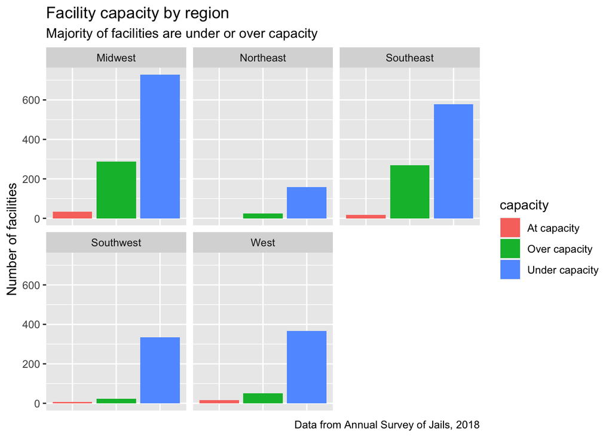

```r
jail_svy %>%
  mutate(capacity = case_when(
    rated > totpop ~ "Under capacity",
    rated == totpop ~ "At capacity",
    rated < totpop ~ "Over capacity"
  )) %>%
  mutate(indic = 1) %>%
  group_by(capacity, region) %>%
  summarize(n = survey_total(indic)) %>%
  ggplot() +
  geom_col(aes(x = capacity, y = n, fill = capacity)) +
  theme(axis.title.x=element_blank(),
        axis.text.x=element_blank(),
        axis.ticks.x=element_blank()) +
  facet_wrap("region") +
  scale_y_continuous(labels = function(x) format(x, scientific = FALSE)) +
  labs(title = "Facility capacity by region",
       subtitle = "Majority of facilities are under or over capacity",
       y = "Number of facilities",
       caption = "Data from Annual Survey of Jails, 2018")
```

## Written Interpretation

In addition to the increased scrutiny about the racial disparities in the criminal justice system, there has also been growing concern about the overcrowding of State prison systems. Based on the data, we concluded that there many more jails under capacity throughout the United States than above capacity. It is important to note that the jail system is different than the prison system, with jails being county-wide and much smaller than state-wide prison systems. The highest number of overcrowded jail facilities are located in the Midwest and the Southeast, but all regions have more jails below capacity than jails above capacity.

## Plot 3

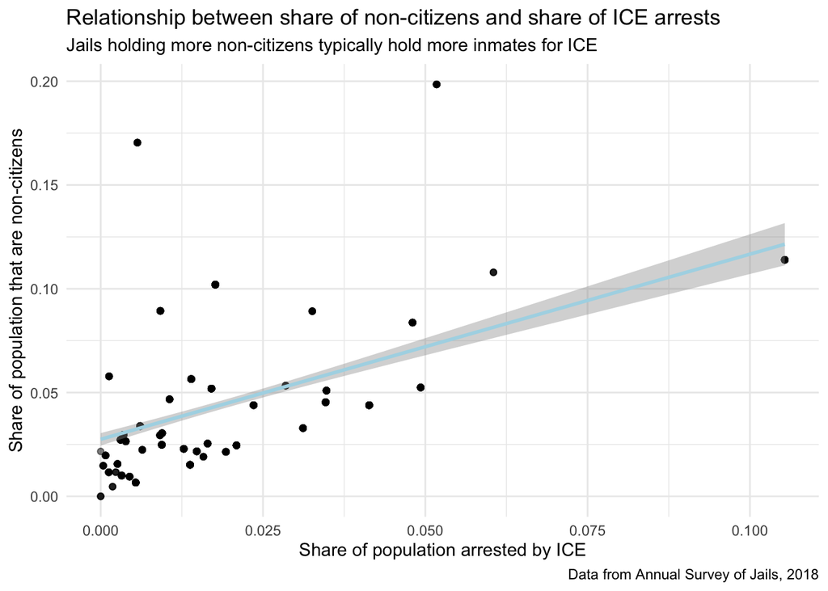

```r
jail_svy %>%
  group_by(state) %>%
  summarize(totnon = survey_total(noncitz),
            totpop = survey_total(totpop),
            statenames = statenames,
            region = region,
            totice = survey_total(ice),
            propnoncit = totnon/totpop,
            propice = totice/totpop) %>%
  ggplot() +
  geom_point(aes(x = propice, y = propnoncit), alpha = 0.5) +
  geom_smooth(aes(x = propice, y = propnoncit), method = "lm", color = "light blue") +
  theme_minimal() +
  labs(title = "Relationship between share of non-citizens and share of ICE arrests",
       x = "Share of population arrested by ICE",
       y = "Share of population that are non-citizens",
       subtitle = "Jails holding more non-citizens typically hold more inmates for ICE",
       caption = "Data from Annual Survey of Jails, 2018")
```